# Child Mortality: Global Causes of Death

11/14/2022

## Aggregated Table

| country | hiv_aids | diarrhoeal_diseases | measles | meningitis | malaria | acute_lower_respiratory_infections | prematurity | birth_asphyxia_trauma | sepsis | other_communicable_diseases | congenital_anomalies | other_noncommunicable_diseases | injuries |
| --- | --- | --- | --- | --- | --- | --- | --- | --- | --- | --- | --- | --- | --- |
| Afghanistan | 512 | 393590 | 128256 | 175548 | 3678 | 684649 | 590851 | 572943 | 264844 | 284977 | 185737 | 180650 | 186197 |
| Angola | 75528 | 720706 | 76792 | 147583 | 389034 | 954335 | 475933 | 517968 | 205322 | 501591 | 225508 | 149764 | 226163 |
| Albania | 16 | 398 | 4 | 694 | 0 | 3421 | 4737 | 1450 | 464 | 1252 | 5046 | 1911 | 2182 |
| Andorra | 0 | 0 | 0 | 0 | 0 | 0 | 66 | 0 | 0 | 0 | 28 | 28 | 0 |
| United Arab Emirates | 44 | 176 | 0 | 326 | 0 | 1172 | 6162 | 2106 | 568 | 2026 | 7381 | 3193 | 2180 |
| Argentina | 807 | 6344 | 0 | 5565 | 0 | 29722 | 109171 | 19405 | 23726 | 26599 | 105968 | 41677 | 28339 |
| Armenia | 86 | 720 | 16 | 573 | 0 | 4702 | 7304 | 2046 | 1304 | 1970 | 6446 | 2155 | 2789 |
| Antigua and Barbuda | 0 | 0 | 0 | 6 | 0 | 30 | 162 | 76 | 8 | 54 | 154 | 114 | 38 |
| Australia | 8 | 154 | 0 | 572 | 6 | 1481 | 9781 | 5193 | 814 | 6750 | 13513 | 7665 | 4140 |
| Austria | 4 | 34 | 0 | 188 | 0 | 223 | 3892 | 798 | 168 | 1060 | 4175 | 1491 | 825 |
| Azerbaijan | 214 | 20389 | 336 | 5486 | 0 | 39458 | 52572 | 30610 | 11368 | 14642 | 24464 | 21546 | 13843 |
| Burundi | 32311 | 145855 | 11296 | 44670 | 167914 | 209784 | 128469 | 130067 | 56794 | 139952 | 50309 | 46048 | 69601 |
| Belgium | 0 | 98 | 0 | 604 | 0 | 479 | 3564 | 1796 | 522 | 2456 | 5930 | 3247 | 1891 |
| Benin | 24974 | 152963 | 27062 | 48048 | 265202 | 210211 | 163318 | 135660 | 89982 | 138983 | 56710 | 51089 | 60244 |
| Burkina Faso | 40268 | 209451 | 151400 | 90499 | 1015638 | 307896 | 257022 | 226214 | 138078 | 191192 | 74964 | 62622 | 86805 |
| Bangladesh | 674 | 668370 | 239950 | 216812 | 1252 | 1268732 | 1124463 | 934026 | 747270 | 661609 | 424704 | 201043 | 405216 |
| Bulgaria | 2 | 482 | 20 | 559 | 0 | 5827 | 5740 | 2250 | 686 | 1494 | 7379 | 2857 | 1778 |
| Bahrain | 6 | 22 | 0 | 56 | 0 | 189 | 1670 | 305 | 92 | 334 | 2245 | 784 | 390 |
| Bahamas | 22 | 24 | 0 | 8 | 0 | 377 | 501 | 239 | 172 | 160 | 391 | 273 | 188 |
| Bosnia and Herzegovina | 0 | 98 | 92 | 152 | 0 | 808 | 2812 | 855 | 328 | 491 | 3052 | 757 | 429 |
| Belarus | 142 | 298 | 0 | 467 | 0 | 2555 | 4778 | 1749 | 470 | 1457 | 7680 | 3069 | 2165 |
| Belize | 103 | 266 | 0 | 82 | 0 | 522 | 976 | 524 | 326 | 492 | 995 | 521 | 457 |
| Bolivia (Plurinational State of) | 1308 | 48681 | 0 | 8643 | 58 | 80039 | 82079 | 66810 | 28664 | 44243 | 55248 | 31478 | 32463 |
| Brazil | 6836 | 118848 | 2 | 42671 | 676 | 237711 | 552665 | 247900 | 215322 | 323816 | 471667 | 213384 | 127839 |
| Barbados | 18 | 6 | 0 | 6 | 0 | 57 | 426 | 305 | 158 | 158 | 348 | 265 | 93 |
| Brunei Darussalam | 6 | 26 | 0 | 16 | 0 | 138 | 501 | 129 | 124 | 240 | 815 | 473 | 186 |
| Bhutan | 132 | 2618 | 340 | 835 | 28 | 5187 | 4414 | 3596 | 2370 | 2436 | 2186 | 1265 | 1900 |
| Botswana | 32650 | 3867 | 2382 | 897 | 82 | 8775 | 20697 | 12763 | 6922 | 6186 | 7127 | 1757 | 2565 |
| Central African Republic | 40268 | 80177 | 26516 | 30534 | 229542 | 116818 | 90507 | 90348 | 39110 | 58485 | 27147 | 17244 | 24524 |
| Canada | 6 | 184 | 0 | 679 | 0 | 1284 | 21598 | 7801 | 2040 | 10196 | 18115 | 8273 | 4629 |

[output cut: 164 more lines]

## Dynamic Paragraph

The most recently recorded leading cause of death for children 0-4 years old is Prematurity, resulting in 964,365 deaths. On the other hand, the disease causing the least number of deaths is HIV/AIDS with 75,360 child deaths. When looking at Prematurity, the country leading this death toll is India with a numerical value of 284,398.

## Chart 1

Here is a bar chart showcasing the correlation between the 13 causes of infant deaths and number of deaths in 2017.

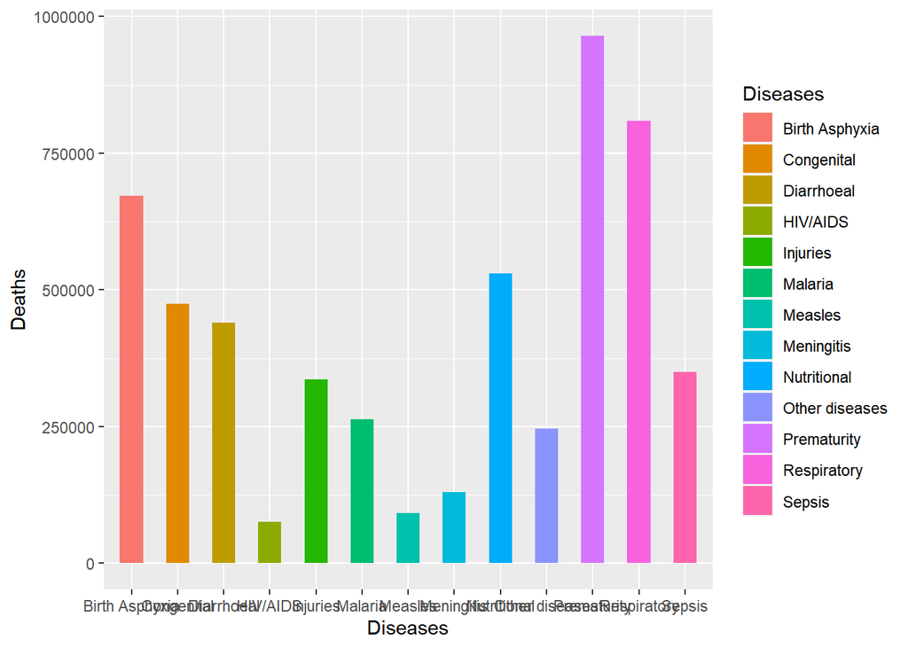

Chart 1, represents the 13 different diseases that lead the world in deaths within children ages 0-4. Having this chart gives a visualization of how big of an impact each disease has had on the death toll. The diseases can be seen on the x-axis, whereas, the number of deaths can be seen on the y-axis. Having a bar chart allows viewers to easily identify which disease has made the most impact on child mortality.

## Chart 2

Here is a pi chart showcasing the amount of deaths for each of the 13 causes in 2017.

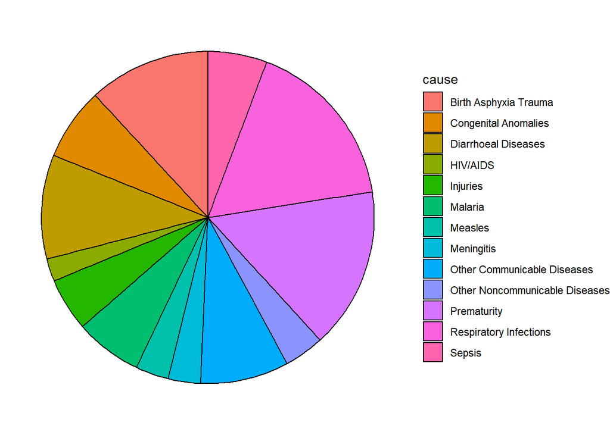

## Chart 3

Here is a map showing where there have been the most child deaths globally from 2000 to 2017.

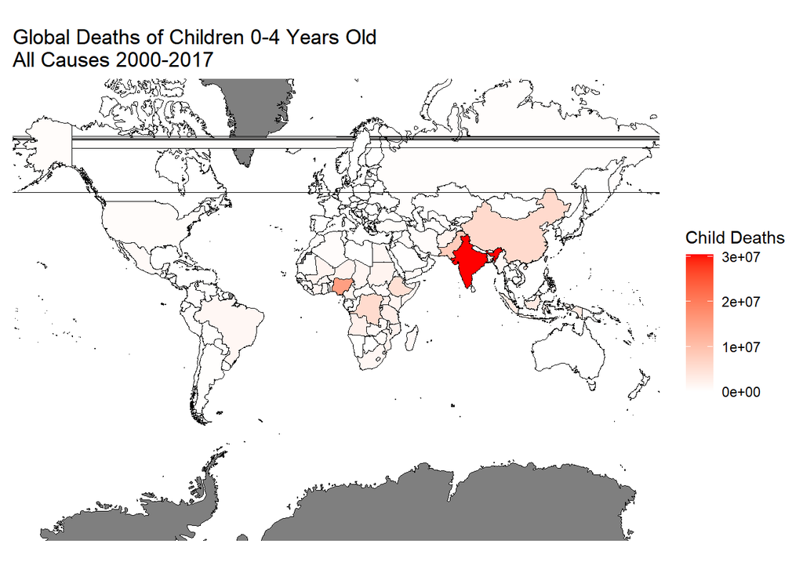

This map shows that certain areas of the world tend to have had more child deaths from 2000 to 2017 from all causes, particularly Central Africa and South and Southeast Asia. But the most obvious statistic is that India has had more than 30,000,000 child deaths for children under five years old in that time span. Certain land areas shown in gray either have no data (Antarctica), or are territories of other countries that do have data (Greenland, considered part of Denmark, and French Guiana, considered a part of France). The horizontal bars and lines across the top appear to be ggplot artifacts of Alaska’s and Russia’s being displayed on either end of the map. Please ignore them, as they are insignificant to the map’s data.